# Case 31: Summary of Data Analysis for R3, R6 and R4

- Show All Code
- Hide All Code
- View Source

Employees Federal Credit Union

Author

Simran Kaur

Published

November 16, 2026

```r
library(tidyverse)
library(haven)
library(knitr)
options(knitr.kable.NA = "")

teal <- "#0D9488"
ink  <- "#052E2B"
loc_pal <- c("Headquarters area" = "#0D9488", "Elsewhere" = "#052E2B")

theme_set(
  theme_minimal(base_size = 15, base_family = "sans") +
    theme(panel.grid.minor = element_blank(),
          plot.title.position = "plot",
          axis.text  = element_text(color = ink, face = "bold"),
          axis.title = element_text(color = ink, face = "bold"),
          legend.text = element_text(color = ink, face = "bold"))
)

efcu <- read_sav("Case 31 Data_efcu_4.sav")
d <- zap_labels(efcu) |>
  mutate(
    q12 = na_if(q12, 3),                                   # "No answer" -> missing
    location = factor(q38, levels = 1:2, labels = c("Headquarters area", "Elsewhere"))
  )

fmt_p <- function(p) ifelse(p < .001, "< .001", sprintf("%.3f", p))

item_labels <- c(
  Att_employee = "Att_employee: Employee proficiency (Q3–Q6)",
  q3  = "Q3: Employees are courteous",
  q4  = "Q4: Employees are helpful",
  q5  = "Q5: Employees are professional",
  q6  = "Q6: Employees are available",
  q9_r  = "Q9r: Statement frequency",
  q10_r = "Q10r: Statement accuracy",
  q31 = "Q31: Personnel keep info confidential",
  q32 = "Q32: Prompt in processing loans",
  q33 = "Q33: Services meet members' needs",
  q34 = "Q34: Loan applications simple",
  Q37_r = "Q37r: Overall management & operation"
)

# One-sample t-test row
one_t <- function(var, mu = 3) {
  x  <- na.omit(d[[var]])
  tt <- t.test(x, mu = mu)
  tibble(Item = item_labels[[var]], n = length(x), Mean = mean(x), SD = sd(x),
         `Test value` = mu, t = unname(tt$statistic), df = unname(tt$parameter),
         p = fmt_p(tt$p.value))
}

# Independent-groups (Welch) t-test row by location
loc_t <- function(var) {
  tt <- t.test(as.formula(paste(var, "~ location")), data = d)
  g  <- d |> group_by(location) |>
    summarise(m = mean(.data[[var]], na.rm = TRUE), s = sd(.data[[var]], na.rm = TRUE))
  tibble(Item = item_labels[[var]],
         `HQ M (SD)`        = sprintf("%.2f (%.2f)", g$m[1], g$s[1]),
         `Elsewhere M (SD)` = sprintf("%.2f (%.2f)", g$m[2], g$s[2]),
         Difference = g$m[1] - g$m[2],
         t  = unname(tt$statistic), df = unname(tt$parameter),
         p  = fmt_p(tt$p.value), p_raw = tt$p.value)
}
```

## 1 About this report

This report answers three research questions using the cleaned Case 31 data (**n = 128 members**).

- **R3:** What are members’ attitudes toward the **proficiency of CU employees**?
- **R6:** How **effectively** do members think the CU is operated?
- **R4:** Do members who live in the **headquarters area** (n = 57) see things differently from those who live **elsewhere** (n = 71)? This covers (a) employee proficiency, (b) awareness of services and (c) operational effectiveness.

**Building on the reliability and factor analysis:** Q3–Q6 formed one reliable factor (α = .87), so employee proficiency is measured with the composite **Att_employee** (the mean of Q3–Q6). Q31–Q34 did **not** form a scale (α = .47), so those four items are analyzed **one by one**. I don’t repeat those results here.

**How to read it:** each section leads with the **finding**. Test statistics are in parentheses and point to the numbered tables and figures. All tests use α = .05. Items ending in **r** are reverse-coded so that **higher = more favorable**.

## 2 R3: Attitudes toward employee proficiency

### 2.1 R3: Descriptive statistics

```r
agree_split <- function(var) {
  x <- na.omit(d[[var]])
  tibble(Item = item_labels[[var]], n = length(x),
         `% disagree (1–2)` = 100 * mean(x <= 2),
         `% uncertain (3)`  = 100 * mean(x == 3),
         `% agree (4–5)`    = 100 * mean(x >= 4),
         Mean = mean(x), SD = sd(x), Median = median(x))
}
map_dfr(c("q3", "q4", "q5", "q6"), agree_split) |> kable(digits = 2)
```

Table 1: Employee proficiency items: % disagree, neutral and agree

| Item | n | % disagree (1–2) | % uncertain (3) | % agree (4–5) | Mean | SD | Median |
| --- | --- | --- | --- | --- | --- | --- | --- |
| Q3: Employees are courteous | 128 | 0.00 | 10.16 | 89.84 | 4.35 | 0.66 | 4 |
| Q4: Employees are helpful | 128 | 0.78 | 10.94 | 88.28 | 4.31 | 0.70 | 4 |
| Q5: Employees are professional | 128 | 0.00 | 17.97 | 82.03 | 4.08 | 0.66 | 4 |
| Q6: Employees are available | 128 | 3.12 | 17.97 | 78.91 | 4.08 | 0.79 | 4 |

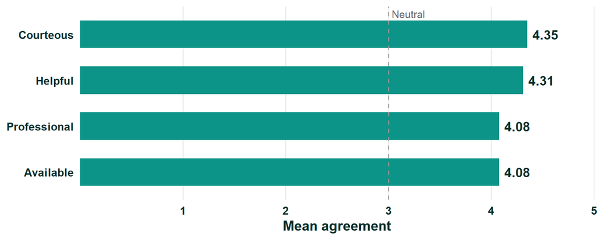

Figure 1: Mean agreement with each employee proficiency statement (1 = strongly disagree, 5 = strongly agree)

```r
d |>
  summarise(across(c(q3, q4, q5, q6), \(x) mean(x, na.rm = TRUE))) |>
  pivot_longer(everything(), names_to = "item", values_to = "mean") |>
  mutate(label = c("Courteous", "Helpful", "Professional", "Available"),
         label = fct_reorder(label, mean)) |>
  ggplot(aes(mean, label)) +
  geom_col(fill = teal, width = 0.6) +
  geom_vline(xintercept = 3, linetype = "dashed", color = "#9a9a9a") +
  annotate("text", x = 3, y = 4.45, label = "Neutral", hjust = -0.1, color = "#6b6b6b", size = 4) +
  geom_text(aes(label = sprintf("%.2f", mean)), hjust = -0.2, color = ink, fontface = "bold", size = 5) +
  scale_x_continuous(limits = c(0, 5), breaks = 1:5, expand = c(0, 0)) +
  labs(x = "Mean agreement", y = NULL) +
  theme(panel.grid.major.y = element_blank())
```

### 2.2 R3: One-sample t-test

```r
map_dfr(c("Att_employee", "q3", "q4", "q5", "q6"), one_t) |> kable(digits = 2)
```

Table 2: Employee proficiency: one-sample t-tests against the scale midpoint (3 = uncertain)

| Item | n | Mean | SD | Test value | t | df | p |
| --- | --- | --- | --- | --- | --- | --- | --- |
| Att_employee: Employee proficiency (Q3–Q6) | 128 | 4.21 | 0.59 | 3 | 22.95 | 127 | < .001 |
| Q3: Employees are courteous | 128 | 4.35 | 0.66 | 3 | 23.20 | 127 | < .001 |
| Q4: Employees are helpful | 128 | 4.31 | 0.70 | 3 | 21.34 | 127 | < .001 |
| Q5: Employees are professional | 128 | 4.08 | 0.66 | 3 | 18.50 | 127 | < .001 |
| Q6: Employees are available | 128 | 4.08 | 0.79 | 3 | 15.44 | 127 | < .001 |

### 2.3 R3: Insight

**Members think highly of EFCU’s employees.**

- The **average attitude toward employee proficiency is 4.21 on a 5-point scale**, firmly between “agree” and “strongly agree,” and **well above neutral** (*M* = 4.21, *t*(127) = 22.95, *p* < .001; Table 2).
- **76% of members average “agree” or higher** across the four statements, and **almost nobody disagrees with any of them** (Table 1).
- Staff are seen as **most courteous (4.35)** and **most helpful (4.31)**. **Professional** and **available** trail slightly (both **4.08**), and availability has the **widest spread** of opinion (*SD* = 0.79; Figure 1).
- **So what:** **staff are a real strength**. If EFCU wants to improve here, **availability** (hours, staffing, wait times) is the one dimension with room to grow.

## 3 R6: Operational effectiveness

### 3.1 R6: Descriptive statistics

```r
fav <- function(var, cut) {
  x <- na.omit(d[[var]])
  tibble(Item = item_labels[[var]], n = length(x),
         `% favorable` = 100 * mean(x >= cut),
         Mean = mean(x), SD = sd(x), Median = median(x))
}
bind_rows(fav("q10_r", 3), fav("q31", 4), fav("q32", 4), fav("q33", 4),
          fav("q34", 4), fav("Q37_r", 4)) |>
  kable(digits = 2)
```

Table 3: Interval items: % favorable and descriptive statistics

| Item | n | % favorable | Mean | SD | Median |
| --- | --- | --- | --- | --- | --- |
| Q10r: Statement accuracy | 128 | 95.31 | 3.47 | 0.64 | 4 |
| Q31: Personnel keep info confidential | 128 | 78.12 | 3.95 | 0.68 | 4 |
| Q32: Prompt in processing loans | 128 | 60.16 | 3.72 | 0.79 | 4 |
| Q33: Services meet members’ needs | 128 | 59.38 | 3.59 | 0.68 | 4 |
| Q34: Loan applications simple | 128 | 57.81 | 3.46 | 0.78 | 4 |
| Q37r: Overall management & operation | 121 | 84.30 | 4.07 | 0.73 | 4 |

*% favorable = good or excellent for Q10r and Q37r, agree or strongly agree for Q31–Q34. Frequencies for the categorical items (Q9, Q11, Q12) are in Table 4.*

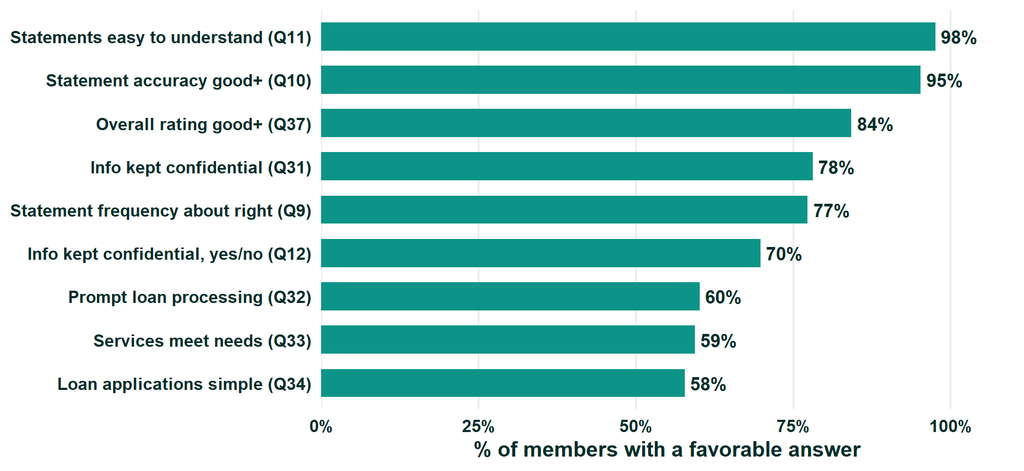

Figure 2: Share of members giving a favorable answer on each operational item

```r
r6_fav <- tibble(
  item = c("Statements easy to understand (Q11)", "Statement accuracy good+ (Q10)",
           "Overall rating good+ (Q37)", "Info kept confidential (Q31)",
           "Statement frequency about right (Q9)", "Info kept confidential, yes/no (Q12)",
           "Prompt loan processing (Q32)", "Services meet needs (Q33)",
           "Loan applications simple (Q34)"),
  pct = c(100 * mean(d$q11 == 1), 100 * mean(d$q10_r >= 3),
          100 * mean(d$Q37_r >= 4, na.rm = TRUE), 100 * mean(d$q31 >= 4),
          100 * mean(d$q9 == 3), 100 * mean(d$q12 == 1, na.rm = TRUE),
          100 * mean(d$q32 >= 4), 100 * mean(d$q33 >= 4), 100 * mean(d$q34 >= 4))
) |>
  mutate(item = fct_reorder(item, pct))

ggplot(r6_fav, aes(pct, item)) +
  geom_col(fill = teal, width = 0.65) +
  geom_text(aes(label = sprintf("%.0f%%", pct)), hjust = -0.15, color = ink,
            fontface = "bold", size = 4.6) +
  scale_x_continuous(limits = c(0, 110), breaks = seq(0, 100, 25),
                     labels = \(x) paste0(x, "%"), expand = c(0, 0)) +
  labs(x = "% of members with a favorable answer", y = NULL) +
  theme(panel.grid.major.y = element_blank())
```

### 3.2 R6: Chi-square goodness-of-fit test

```r
gof <- function(var, labels, item) {
  tab <- table(factor(d[[var]], levels = names(labels)))
  tab <- tab[tab > 0]
  ct  <- chisq.test(tab)
  tibble(Item = item, Response = unname(labels[names(tab)]), n = as.integer(tab),
         Percent = 100 * as.integer(tab) / sum(tab),
         `Chi-square` = c(unname(ct$statistic), rep(NA, length(tab) - 1)),
         df = c(unname(ct$parameter), rep(NA, length(tab) - 1)),
         p  = c(fmt_p(ct$p.value), rep("", length(tab) - 1)))
}
bind_rows(
  gof("q9",  c("1" = "Too often", "2" = "Very often", "3" = "About right",
               "4" = "Not often enough", "5" = "Never"), "Q9: Statement frequency"),
  gof("q11", c("1" = "Yes", "2" = "No"), "Q11: Statements easy to understand"),
  gof("q12", c("1" = "Yes", "2" = "No"), "Q12: Account info kept confidential")
) |> kable(digits = 1)
```

Table 4: Frequency and yes/no items: frequencies and chi-square goodness-of-fit tests

| Item | Response | n | Percent | Chi-square | df | p |
| --- | --- | --- | --- | --- | --- | --- |
| Q9: Statement frequency | About right | 99 | 77.3 | 38.3 | 1 | < .001 |
| Q9: Statement frequency | Not often enough | 29 | 22.7 |  |  |  |
| Q11: Statements easy to understand | Yes | 125 | 97.7 | 116.3 | 1 | < .001 |
| Q11: Statements easy to understand | No | 3 | 2.3 |  |  |  |
| Q12: Account info kept confidential | Yes | 74 | 69.8 | 16.6 | 1 | < .001 |
| Q12: Account info kept confidential | No | 32 | 30.2 |  |  |  |

### 3.3 R6: One-sample t-test

```r
bind_rows(
  one_t("q10_r", mu = 2.5),
  one_t("q31"), one_t("q32"), one_t("q33"), one_t("q34"),
  one_t("Q37_r")
) |> kable(digits = 2)
```

Table 5: Interval items: one-sample t-tests against the scale midpoint (2.5 for the 4-point Q10r, 3 otherwise)

| Item | n | Mean | SD | Test value | t | df | p |
| --- | --- | --- | --- | --- | --- | --- | --- |
| Q10r: Statement accuracy | 128 | 3.47 | 0.64 | 2.5 | 17.15 | 127 | < .001 |
| Q31: Personnel keep info confidential | 128 | 3.95 | 0.68 | 3.0 | 15.74 | 127 | < .001 |
| Q32: Prompt in processing loans | 128 | 3.72 | 0.79 | 3.0 | 10.25 | 127 | < .001 |
| Q33: Services meet members’ needs | 128 | 3.59 | 0.68 | 3.0 | 9.87 | 127 | < .001 |
| Q34: Loan applications simple | 128 | 3.46 | 0.78 | 3.0 | 6.66 | 127 | < .001 |
| Q37r: Overall management & operation | 121 | 4.07 | 0.73 | 3.0 | 16.12 | 120 | < .001 |

### 3.4 R6: Insight

**Members think EFCU is WELL RUN, with two soft spots: statement frequency and privacy doubts.**

- **At a glance:** most items are **favorable for 58–98% of members**. **Loan paperwork, meeting needs and loan speed** sit at the bottom, at roughly **60%** (Figure 2).
- **Overall:** **84% rate management and operations good or excellent** (Table 3; Q37r *M* = 4.07, *t*(120) = 16.12, *p* < .001; Table 5).
- **Statements are clear and accurate.** **98% find them easy to understand** (χ²(1) = 116.3, *p* < .001; Table 4), and accuracy averages **3.47 of 4** (*t*(127) = 17.15, *p* < .001).
- **But 23% say statements don’t come often enough**, and **nobody** says too often (χ²(1) = 38.3, *p* < .001). That’s an **easy fix**.
- **Privacy:** **78% agree staff keep information confidential** (Q31 *M* = 3.95, *p* < .001). But on the yes/no version, **30% said no** (Q12, χ²(1) = 16.6, *p* < .001), a **warning sign** for a financial institution.
- **Loans and services:** all rated **above neutral** (all *p* < .001). **Prompt processing (3.72)** scores best, then **meeting needs (3.59)**. **Simple applications (3.46)** scores lowest.
- **So what:** keep doing what works. **Send statements more often**, **review how privacy is communicated**, and **simplify loan paperwork**.

## 4 R4: Headquarters area vs. elsewhere

### 4.1 R4a: Descriptive statistics

```r
d |>
  group_by(Location = location) |>
  summarise(n = n(),
            `% agree (Att ≥ 4)` = 100 * mean(Att_employee >= 4),
            `Att_employee M` = mean(Att_employee), SD = sd(Att_employee),
            Q3 = mean(q3), Q4 = mean(q4), Q5 = mean(q5), Q6 = mean(q6)) |>
  kable(digits = 2)
```

Table 6: Employee proficiency by location: % agree and means

| Location | n | % agree (Att ≥ 4) | Att_employee M | SD | Q3 | Q4 | Q5 | Q6 |
| --- | --- | --- | --- | --- | --- | --- | --- | --- |
| Headquarters area | 57 | 82.46 | 4.28 | 0.57 | 4.40 | 4.39 | 4.16 | 4.18 |
| Elsewhere | 71 | 70.42 | 4.14 | 0.61 | 4.31 | 4.25 | 4.01 | 4.00 |

### 4.2 R4a: Independent-samples t-test

```r
map_dfr(c("Att_employee", "q3", "q4", "q5", "q6"), loc_t) |>
  select(-p_raw) |>
  kable(digits = 2)
```

Table 7: Employee proficiency by location: independent-groups (Welch) t-tests

| Item | HQ M (SD) | Elsewhere M (SD) | Difference | t | df | p |
| --- | --- | --- | --- | --- | --- | --- |
| Att_employee: Employee proficiency (Q3–Q6) | 4.28 (0.57) | 4.14 (0.61) | 0.14 | 1.30 | 122.49 | 0.195 |
| Q3: Employees are courteous | 4.40 (0.68) | 4.31 (0.65) | 0.09 | 0.79 | 117.46 | 0.429 |
| Q4: Employees are helpful | 4.39 (0.70) | 4.25 (0.69) | 0.13 | 1.07 | 119.37 | 0.287 |
| Q5: Employees are professional | 4.16 (0.62) | 4.01 (0.69) | 0.14 | 1.24 | 124.18 | 0.216 |
| Q6: Employees are available | 4.18 (0.73) | 4.00 (0.83) | 0.18 | 1.27 | 124.70 | 0.207 |

### 4.3 R4a: Insight

**Location makes NO difference to how members see employees.**

### 4.4 R4b: Descriptive statistics (cross-tabulation)

```r
services <- c(
  q13_r = "Regular share accounts", q14_r = "Special subaccounts",
  q15_r = "Christmas club accounts", q16_r = "IRAs",
  q17_r = "MasterCard credit card", q18_r = "Signature loans",
  q19_r = "New car loans", q20_r = "Late model car loans",
  q21_r = "Older model car loans", q22_r = "Household goods loans",
  q23_r = "Recreational loans", q24_r = "Share collateralized loans",
  q25_r = "IRA loans", q26_r = "Line of credit loans"
)
r4b <- map_dfr(names(services), function(v) {
  tab <- table(d$location, factor(d[[v]], levels = 1:3))
  tab <- tab[, colSums(tab) > 0, drop = FALSE]
  ct  <- suppressWarnings(chisq.test(tab))
  hq  <- d[[v]][d$q38 == 1]; el <- d[[v]][d$q38 == 2]
  tibble(Service = services[[v]],
         `HQ % unaware` = 100 * mean(hq == 1), `Else % unaware` = 100 * mean(el == 1),
         `HQ % used`    = 100 * mean(hq == 3), `Else % used`    = 100 * mean(el == 3),
         `Chi-square` = unname(ct$statistic), df = unname(ct$parameter),
         p = fmt_p(ct$p.value), `Fisher p` = fmt_p(fisher.test(tab)$p.value))
})
r4b |> select(Service:`Else % used`) |> kable(digits = 0)
```

Table 8: Awareness of services by location: % unaware and % who have used each service

| Service | HQ % unaware | Else % unaware | HQ % used | Else % used |
| --- | --- | --- | --- | --- |
| Regular share accounts | 60 | 69 | 12 | 8 |
| Special subaccounts | 39 | 34 | 7 | 11 |
| Christmas club accounts | 30 | 35 | 9 | 8 |
| IRAs | 28 | 27 | 25 | 21 |
| MasterCard credit card | 18 | 7 | 44 | 44 |
| Signature loans | 7 | 1 | 14 | 15 |
| New car loans | 4 | 4 | 18 | 20 |
| Late model car loans | 14 | 6 | 11 | 11 |
| Older model car loans | 26 | 25 | 7 | 11 |
| Household goods loans | 33 | 25 | 9 | 8 |
| Recreational loans | 39 | 46 | 9 | 11 |
| Share collateralized loans | 54 | 54 | 2 | 1 |
| IRA loans | 63 | 59 | 0 | 6 |
| Line of credit loans | 0 | 0 | 35 | 39 |

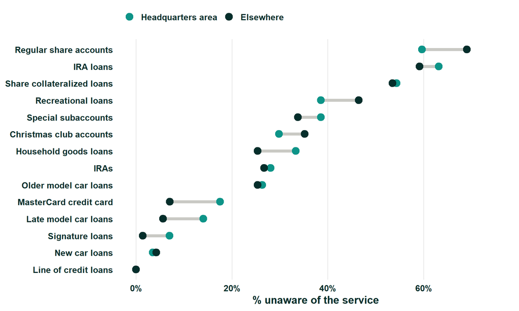

Figure 3: Percent of members UNAWARE of each service, headquarters area vs. elsewhere

```r
r4b |>
  select(Service, `Headquarters area` = `HQ % unaware`, Elsewhere = `Else % unaware`) |>
  pivot_longer(-Service, names_to = "location", values_to = "pct") |>
  mutate(location = factor(location, levels = names(loc_pal)),
         Service = fct_reorder(Service, pct, .fun = mean)) |>
  ggplot(aes(pct, Service)) +
  geom_line(aes(group = Service), color = "#c9c9c4", linewidth = 2) +
  geom_point(aes(color = location), size = 4.5) +
  scale_color_manual(values = loc_pal) +
  scale_x_continuous(limits = c(0, 75), labels = \(x) paste0(x, "%")) +
  labs(x = "% unaware of the service", y = NULL, color = NULL) +
  theme(legend.position = "top", legend.justification = "left",
        panel.grid.major.y = element_blank())
```

### 4.5 R4b: Chi-square test of independence

```r
r4b |> select(Service, `Chi-square`, df, p, `Fisher p`) |> kable(digits = 2)
```

Table 9: Awareness by location: chi-square tests of independence (Fisher’s exact p shown because some expected counts are below 5)

| Service | Chi-square | df | p | Fisher p |
| --- | --- | --- | --- | --- |
| Regular share accounts | 1.27 | 2 | 0.529 | 0.543 |
| Special subaccounts | 0.81 | 2 | 0.666 | 0.722 |
| Christmas club accounts | 0.42 | 2 | 0.810 | 0.860 |
| IRAs | 0.33 | 2 | 0.849 | 0.869 |
| MasterCard credit card | 3.79 | 2 | 0.150 | 0.158 |
| Signature loans | 2.66 | 2 | 0.265 | 0.319 |
| New car loans | 0.16 | 2 | 0.925 | 0.938 |
| Late model car loans | 2.63 | 2 | 0.269 | 0.287 |
| Older model car loans | 0.67 | 2 | 0.714 | 0.732 |
| Household goods loans | 1.05 | 2 | 0.592 | 0.622 |
| Recreational loans | 1.38 | 2 | 0.502 | 0.519 |
| Share collateralized loans | 0.04 | 2 | 0.981 | 1.000 |
| IRA loans | 3.32 | 2 | 0.190 | 0.242 |
| Line of credit loans | 0.10 | 1 | 0.748 | 0.714 |

### 4.6 R4b: Insight

**Awareness gaps are the SAME everywhere. Location doesn’t explain who knows what.**

- The awareness percentages look **almost identical** in the two locations, and the two dots sit close together for nearly every service (Table 8, Figure 3), and **none of the 14 services** shows a significant difference (all *p* ≥ .15; Table 9). Fisher’s exact tests, used because some cells are small, agree.
- The **biggest raw gap** is the **MasterCard**: **18% of HQ-area members are unaware vs. 7% elsewhere**, but even that isn’t significant (χ²(2) = 3.79, *p* = .150).
- The **low-awareness services**, like **IRA loans (about 60% unaware)** and **share-collateralized loans (54%)**, are **just as unknown** in the HQ area as outside it.
- **So what:** EFCU’s awareness problem is **CU-wide, not regional**. One **member-wide campaign** fits better than location-targeted messaging.

### 4.7 R4c: Descriptive statistics

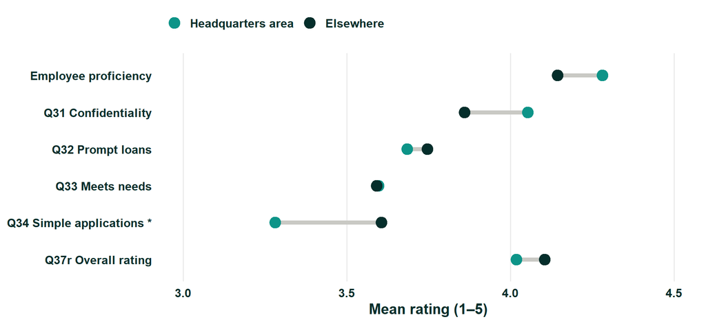

Figure 4: Mean ratings by location. Only Q34 (simple loan applications) differs significantly

```r
plot_items <- c("Att_employee", "q31", "q32", "q33", "q34", "Q37_r")
short <- c(Att_employee = "Employee proficiency", q31 = "Q31 Confidentiality",
           q32 = "Q32 Prompt loans", q33 = "Q33 Meets needs",
           q34 = "Q34 Simple applications *", Q37_r = "Q37r Overall rating")
d |>
  select(location, all_of(plot_items)) |>
  pivot_longer(-location, names_to = "item", values_to = "value") |>
  group_by(item, location) |>
  summarise(mean = mean(value, na.rm = TRUE), .groups = "drop") |>
  mutate(item = factor(short[item], levels = rev(short[plot_items]))) |>
  ggplot(aes(mean, item)) +
  geom_line(aes(group = item), color = "#c9c9c4", linewidth = 2) +
  geom_point(aes(color = location), size = 5) +
  scale_color_manual(values = loc_pal) +
  scale_x_continuous(limits = c(3, 4.5)) +
  labs(x = "Mean rating (1–5)", y = NULL, color = NULL) +
  theme(legend.position = "top", legend.justification = "left",
        panel.grid.major.y = element_blank())
```

### 4.8 R4c: Independent-samples t-test

```r
r4c <- map_dfr(c("q9_r", "q10_r", "q31", "q32", "q33", "q34", "Q37_r"), loc_t)
r4c |> select(-p_raw) |> kable(digits = 2)
```

Table 10: Operational effectiveness by location: independent-groups (Welch) t-tests

| Item | HQ M (SD) | Elsewhere M (SD) | Difference | t | df | p |
| --- | --- | --- | --- | --- | --- | --- |
| Q9r: Statement frequency | 2.79 (0.41) | 2.76 (0.43) | 0.03 | 0.39 | 122.13 | 0.699 |
| Q10r: Statement accuracy | 3.49 (0.66) | 3.45 (0.63) | 0.04 | 0.35 | 117.53 | 0.724 |
| Q31: Personnel keep info confidential | 4.05 (0.67) | 3.86 (0.68) | 0.19 | 1.62 | 121.26 | 0.109 |
| Q32: Prompt in processing loans | 3.68 (0.81) | 3.75 (0.79) | -0.06 | -0.44 | 118.94 | 0.661 |
| Q33: Services meet members’ needs | 3.60 (0.73) | 3.59 (0.65) | 0.00 | 0.04 | 112.93 | 0.968 |
| Q34: Loan applications simple | 3.28 (0.92) | 3.61 (0.62) | -0.32 | -2.28 | 94.24 | 0.025 |
| Q37r: Overall management & operation | 4.02 (0.66) | 4.10 (0.78) | -0.09 | -0.66 | 118.74 | 0.513 |

### 4.9 R4c: Chi-square test of independence

```r
map_dfr(c(q11 = "Q11: Statements easy to understand", q12 = "Q12: Account info kept confidential") |>
          imap(\(lab, v) list(v = v, lab = lab)), function(x) {
  tab <- table(d$location, d[[x$v]])
  ct  <- suppressWarnings(chisq.test(tab, correct = FALSE))
  tibble(Item = x$lab,
         `HQ % yes`   = 100 * tab[1, 1] / sum(tab[1, ]),
         `Else % yes` = 100 * tab[2, 1] / sum(tab[2, ]),
         `Chi-square` = unname(ct$statistic), df = unname(ct$parameter),
         p = fmt_p(ct$p.value), `Fisher p` = fmt_p(fisher.test(tab)$p.value))
}) |> kable(digits = 1)
```

Table 11: Yes/no items by location: chi-square tests of independence

| Item | HQ % yes | Else % yes | Chi-square | df | p | Fisher p |
| --- | --- | --- | --- | --- | --- | --- |
| Q11: Statements easy to understand | 96.5 | 98.6 | 0.6 | 1 | 0.435 | 0.585 |
| Q12: Account info kept confidential | 63.3 | 75.4 | 1.9 | 1 | 0.173 | 0.206 |

### 4.10 R4c: Insight

**Operations are rated the same in both locations, with ONE exception: HQ-area members find loan applications LESS simple.**

## 5 Summary

[output not shown]

## 6 Appendix

- **GitHub Pages:** https://simrank-dm.github.io/IBM6500-F26/IC-Case31-Summary-R3-R6-R4/IC-Case31-Summary-R3-R6-R4-Simran-Kaur.html
- **GitHub Repository:** https://github.com/Simrank-DM/IBM6500-F26